# HW 01: PREDICCIÓN DE VENTAS DE APPLE (AAPL)

**Alejandro José Gómez Rivas**

Asignatura: Técnicas de predicción - series temporales

## Paquetes

```python
import pandas as pd
import numpy as np
import matplotlib.pyplot as plt
import seaborn as sns
import statsmodels.api as sm
from sktime.forecasting.base import ForecastingHorizon
from sktime.utils.plotting import plot_series
from sktime.forecasting.model_selection import temporal_train_test_split
from sktime.forecasting.ets import AutoETS
from sktime.performance_metrics.forecasting import mean_absolute_percentage_error
from sktime.performance_metrics.forecasting import MeanSquaredError
from sktime.forecasting.exp_smoothing import ExponentialSmoothing
import warnings
warnings.filterwarnings('ignore')
from sktime.transformations.series.boxcox import LogTransformer
from sktime.utils.plotting import plot_correlations
from sktime.transformations.series.difference import Differencer
from sktime.forecasting.arima import AutoARIMA
```

## 1. Lectura y preparación de los datos temporales

```python
apple_df = pd.read_csv('aapl.csv', sep=';', decimal=',')

apple_df['fecha'] =  pd.to_datetime(apple_df['fecha'])

apple_df = apple_df.set_index('fecha')

apple_df
```

| fecha | Trimeste | Ingresos |
| --- | --- | --- |
| 1989-12-29 | Q1 1990 | 1493.4 |
| 1990-03-30 | Q2 1990 | 1346.2 |
| 1990-06-29 | Q3 1990 | 1364.8 |
| 1990-09-28 | Q4 1990 | 1354.1 |
| 1990-12-28 | Q1 1991 | 1675.5 |
| ... | ... | ... |
| 2020-06-27 | Q3 2020 | 59685.0 |
| 2020-09-26 | Q4 2020 | 64698.0 |
| 2020-12-26 | Q1 2021 | 111439.0 |
| 2021-03-27 | Q2 2021 | 89584.0 |
| 2021-06-26 | Q3 2021 | 81434.0 |

127 rows × 2 columns

Como las fechas no están en la frecuencia que se desea, se realiza un remuestreo con **"resample"** y se conversa a formato trimestral fiscal, o sea, en vez de empezar en enero como en un año natural, se empieza en octubre, que es cuando Apple empieza su año fiscal:

```python
apple_ts_f = apple_df.resample("Q-OCT").last()

apple_ts_anual_f = apple_ts_f.asfreq('Q-OCT').resample('A-OCT').sum()

apple_ts_f
```

| fecha | Trimeste | Ingresos |
| --- | --- | --- |
| 1990-01-31 | Q1 1990 | 1493.4 |
| 1990-04-30 | Q2 1990 | 1346.2 |
| 1990-07-31 | Q3 1990 | 1364.8 |
| 1990-10-31 | Q4 1990 | 1354.1 |
| 1991-01-31 | Q1 1991 | 1675.5 |
| ... | ... | ... |
| 2020-07-31 | Q3 2020 | 59685.0 |
| 2020-10-31 | Q4 2020 | 64698.0 |
| 2021-01-31 | Q1 2021 | 111439.0 |
| 2021-04-30 | Q2 2021 | 89584.0 |
| 2021-07-31 | Q3 2021 | 81434.0 |

127 rows × 2 columns

```python
apple_ts_anual_f.head(n=10)
```

| fecha | Ingresos |
| --- | --- |
| 1990-10-31 | 5558.5 |
| 1991-10-31 | 6308.9 |
| 1992-10-31 | 7086.5 |
| 1993-10-31 | 7977.0 |
| 1994-10-31 | 9188.8 |
| 1995-10-31 | 11062.0 |
| 1996-10-31 | 9833.0 |
| 1997-10-31 | 7081.0 |
| 1998-10-31 | 5941.0 |
| 1999-10-31 | 6134.0 |

A continuación, se realiza una sencilla gráfica de línea para observar cómo se comportan las ventas:

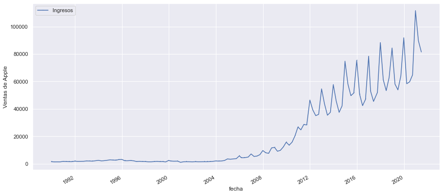

```python
sns.set(rc={'figure.figsize':(15, 7)})

ax = apple_df.plot(marker=',', linestyle='-')

ax.set_ylabel('Ventas de Apple');
```

Ahora, se va a realizar un análisis de la estacionalidad mediante el cálculo de su media y varianza:

```python
def split_and_summarize(dataframe, column, size, fn):
    ranges = []
    values = []
    for i in range(0, len(dataframe), size):
        ranges.append(dataframe[i:i + size])
    for i in ranges:
        values.append(fn(i[column]))
    return(values)
```

```python
mean = split_and_summarize(apple_df, 'Ingresos', 4, np.mean)

variance = split_and_summarize(apple_df, 'Ingresos', 4, np.var)
```

Ahora, se grafican las medias y varianzas obtenidas:

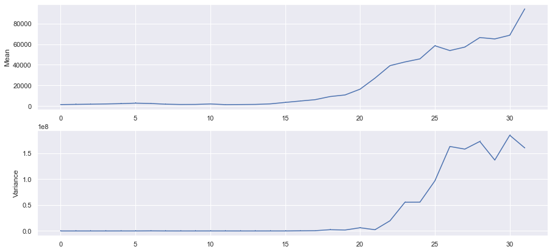

```python
cols = ['mean', 'variance']
df = pd.DataFrame([mean, variance], index=cols)

sns.set(rc={'figure.figsize':(15, 7)})
fig, (ax1, ax2) = plt.subplots(2, 1)

ax1.plot(mean, ',-')
ax1.set_ylabel('Mean')

ax2.plot(variance, ',-')
ax2.set_ylabel('Variance')

plt.show()
```

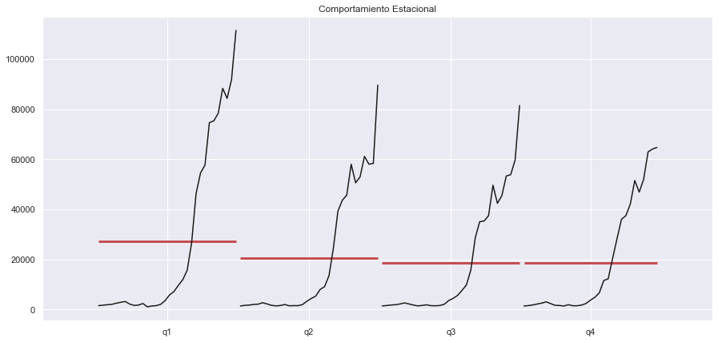

```python
# Se grafican los ventas por trimestres para analizar su comportamiento estacional:
ax = plt.gca()
sm.graphics.tsa.quarter_plot(apple_ts_f['Ingresos'], ax=ax)
ax.set_title('Comportamiento Estacional');
```

Como análisis de las gráficas, se observa:

- Existe una clara tendencia creciente positiva en la gráfica de ventas de Apple.
- Hay un componente estacional que no es estacionario.
- Los ingresos de Apple no son estacionarios ni en media ni en varianza, fluctúan y se comportan con una tendencia alcista con el tiempo.
- Las ventas dependen del trimestre, existen más ventas en el Q1 (año fiscal), coincidente con cuarto trimestre en un año natural. El motivo es por las presentaciones de los nuevos productos de Apple y por el incremento de ventas que suele haber en esas fechas como el Black Friday o el periodo navideño.

### Ventas anuales de Apple:

En este apartado, se realizará una gráfica de las ventas anuales de la marca de Cupertino:

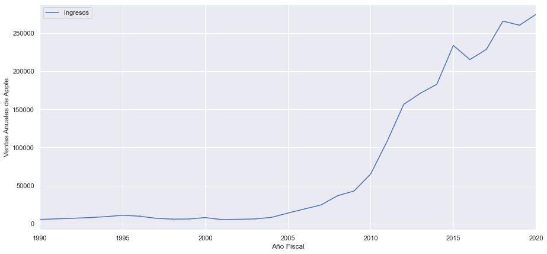

```python
ax = apple_ts_anual_f[:'2020'].plot(marker=',', linestyle='-')

ax.set_ylabel('Ventas Anuales de Apple')

ax.set_xlabel('Año Fiscal');
```

El crecimiento de los ingresos son los siguientes:

```python
apple_growth = apple_ts_anual_f.pct_change().mul(100).dropna()

mean = apple_growth.mean()

apple_growth.tail()

mean
```

```
Ingresos    15.990132
dtype: float64
```

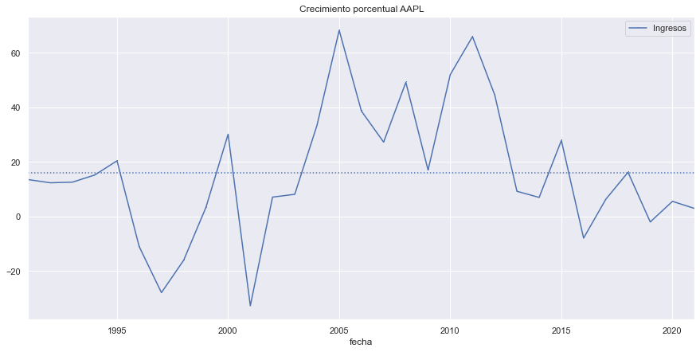

```python
ax = apple_growth.plot(marker=',', linestyle='-')

ax.set_title('Crecimiento porcentual AAPL')

ax.axhline(15.990132, linestyle='dotted');
```

## II. Modelos de suavizado exponencial

A continuación, se realiza una segmentación en la estimación y en la parte de predicción (Training-Testing), prediciéndolo en un año.

```
119 8
```

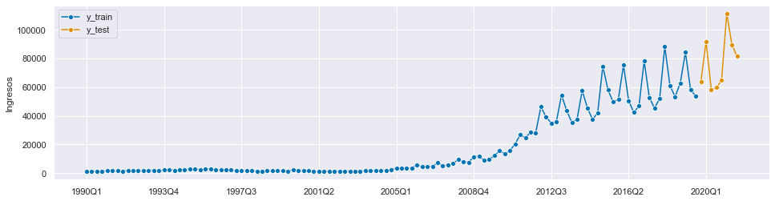

```python
y_train, y_test = temporal_train_test_split(y = apple_ts_f['Ingresos'].astype('float64').to_period('Q-OCT'), test_size=8)

plot_series(y_train, y_test, labels=["y_train", "y_test"])

print(y_train.shape[0], y_test.shape[0])
```

Se realiza el pronóstico (forecasting) del horizonte temporal de 8 Qs, que son los que se dejan para realizar el testing:

```python
fh = np.arange(1, 9)

apple_auto_model = AutoETS(auto=True, sp=4, n_jobs=-1)

apple_auto_model.fit(y_train)

print(apple_auto_model.summary())
```

```
                                 ETS Results
==============================================================================
Dep. Variable:               Ingresos   No. Observations:                  119
Model:                       ETS(MAM)   Log Likelihood                -968.025
Date:                Tue, 02 Nov 2021   AIC                           1956.050
Time:                        10:35:45   BIC                           1983.841
Sample:                    01-31-1990   HQIC                          1967.335
                         - 07-31-2019   Scale                            0.018
Covariance Type:               approx
======================================================================================
                         coef    std err          z      P>|z|      [0.025      0.975]
--------------------------------------------------------------------------------------
smoothing_level        0.4225      0.055      7.739      0.000       0.316       0.530
smoothing_trend        0.1685      0.034      4.890      0.000       0.101       0.236
smoothing_seasonal     0.3568      0.077      4.646      0.000       0.206       0.507
initial_level       1370.9326    598.928      2.289      0.022     197.055    2544.810
initial_trend         46.0330     96.115      0.479      0.632    -142.349     234.415
initial_seasonal.0     0.8649      0.393      2.199      0.028       0.094       1.636
initial_seasonal.1     0.8891      0.402      2.210      0.027       0.101       1.678
initial_seasonal.2     0.9181      0.414      2.216      0.027       0.106       1.730
initial_seasonal.3     1.0000      0.441      2.265      0.024       0.135       1.865
===================================================================================
Ljung-Box (Q):                        5.15   Jarque-Bera (JB):               112.84
Prob(Q):                              0.74   Prob(JB):                         0.00
Heteroskedasticity (H):               1.20   Skew:                            -0.39
Prob(H) (two-sided):                  0.57   Kurtosis:                         7.71
===================================================================================

Warnings:
[1] Covariance matrix calculated using numerical (complex-step) differentiation.
```

Consulta de las predicciones:

```python
apple_pred = apple_auto_model.predict(fh)

print(apple_pred)
```

```
2019Q4    58581.328203
2020Q1    85963.044336
2020Q2    59751.802023
2020Q3    53079.529069
2020Q4    58323.470270
2021Q1    85584.243225
2021Q2    59488.211881
2021Q3    52845.114583
Freq: Q-OCT, dtype: float64
```

Se grafican las series para revisarlos con las predicciones:

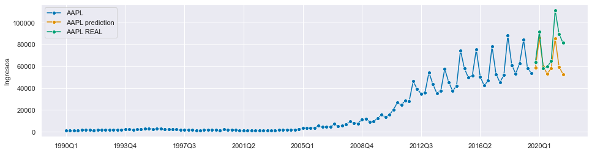

```python
plot_series(y_train, apple_pred, y_test, labels=["AAPL", "AAPL prediction", "AAPL REAL"]);
```

Se hace un zoom al gráfico desde el 2015 para observar mejor las predicciones:

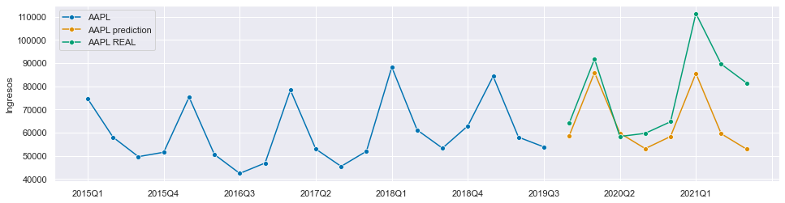

```python
plot_series(y_train["2015":], apple_pred,y_test, labels=["AAPL", "AAPL prediction", "AAPL REAL"]);
```

La predicción por ETS está por debajo de la línea de los datos reales, por lo que se concluye que Apple ha mejorado por encima de dicha predicción.

#### Comprobación de la precisión de las predicciones (errores):

MAPE

```python
mape = mean_absolute_percentage_error(y_test, apple_pred)
```

```python
mape
```

```
0.18651415706682006
```

MSE

```python
mse = MeanSquaredError()
mse(y_test, apple_pred)
```

```
317746952.6259897
```

RMSE

```python
rmse = MeanSquaredError(square_root=True)
rmse(y_test, apple_pred)
```

```
17825.457992040196
```

Ahora se realiza el pronóstico (forecasting) del horizonte temporal de 6 Qs, o sea, para el final del 2021 y el 2022:

```python
fh2 = np.arange(1, 7)

apple_auto_model = AutoETS(auto=True, sp=4, n_jobs=-1)

y = apple_ts_f['Ingresos'].astype('float64').to_period('Q-OCT')

apple_auto_model.fit(y)

print(apple_auto_model.summary())
```

```
                                 ETS Results
==============================================================================
Dep. Variable:               Ingresos   No. Observations:                  127
Model:                       ETS(MAM)   Log Likelihood               -1052.310
Date:                Tue, 02 Nov 2021   AIC                           2124.620
Time:                        10:35:46   BIC                           2153.062
Sample:                    01-31-1990   HQIC                          2136.176
                         - 07-31-2021   Scale                            0.018
Covariance Type:               approx
======================================================================================
                         coef    std err          z      P>|z|      [0.025      0.975]
--------------------------------------------------------------------------------------
smoothing_level        0.4303      0.055      7.816      0.000       0.322       0.538
smoothing_trend        0.1718      0.035      4.969      0.000       0.104       0.240
smoothing_seasonal     0.3322      0.075      4.430      0.000       0.185       0.479
initial_level       1370.9326    598.701      2.290      0.022     197.501    2544.364
initial_trend         46.0330     96.851      0.475      0.635    -143.792     235.858
initial_seasonal.0     0.8695      0.395      2.203      0.028       0.096       1.643
initial_seasonal.1     0.8897      0.402      2.213      0.027       0.102       1.678
initial_seasonal.2     0.9175      0.414      2.218      0.027       0.107       1.728
initial_seasonal.3     1.0000      0.442      2.265      0.024       0.135       1.865
===================================================================================
Ljung-Box (Q):                        5.73   Jarque-Bera (JB):               109.32
Prob(Q):                              0.68   Prob(JB):                         0.00
Heteroskedasticity (H):               0.88   Skew:                            -0.35
Prob(H) (two-sided):                  0.67   Kurtosis:                         7.49
===================================================================================

Warnings:
[1] Covariance matrix calculated using numerical (complex-step) differentiation.
```

#### Predicción de las ventas los 6 futuros trimestres por modelo ETS:

```python
apple_auto_model.predict(fh2)
```

```
2021Q4     94928.194990
2022Q1    153907.748322
2022Q2    112068.403689
2022Q3    104446.055221
2022Q4    120404.558467
2023Q1    192615.693011
Freq: Q-OCT, dtype: float64
```

La representación gráfica de las predicciones a futuro de las ventas de Apple (2021-Q3 a 2022-Q4):

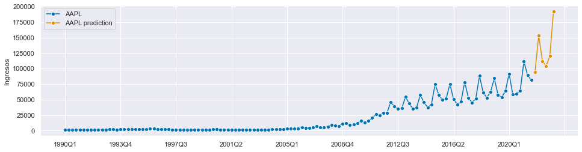

```python
plot_series(y, apple_auto_model.predict(fh2), labels=["AAPL", "AAPL prediction"]);
```

#### Estimación del modelo de forma manual:

```python
forecaster = ExponentialSmoothing(trend='additive', seasonal='multiplicative', sp=4)
forecaster.fit(y)
```

```
ExponentialSmoothing(seasonal='multiplicative', sp=4, trend='additive')
```

```python
y_pred = forecaster.predict(fh2)
y_pred
```

```
2021Q4     89911.087953
2022Q1    140067.871689
2022Q2     98561.116899
2022Q3     88902.618892
2022Q4     97928.137407
2023Q1    152284.884957
Freq: Q-OCT, dtype: float64
```

```python
print(forecaster._fitted_forecaster.summary())
```

```
                       ExponentialSmoothing Model Results
================================================================================
Dep. Variable:                 Ingresos   No. Observations:                  127
Model:             ExponentialSmoothing   SSE                     1632170490.192
Optimized:                         True   AIC                           2094.862
Trend:                         Additive   BIC                           2117.615
Seasonal:                Multiplicative   AICC                          2096.758
Seasonal Periods:                     4   Date:                 Tue, 02 Nov 2021
Box-Cox:                          False   Time:                         10:35:46
Box-Cox Coeff.:                    None
=================================================================================
                          coeff                 code              optimized
---------------------------------------------------------------------------------
smoothing_level               0.7121429                alpha                 True
smoothing_trend               0.0593452                 beta                 True
smoothing_seasonal            0.2878571                gamma                 True
initial_level                 1370.9325                  l.0                 True
initial_trend                 46.033636                  b.0                 True
initial_seasons.0             1.1043189                  s.0                 True
initial_seasons.1             0.9887044                  s.1                 True
initial_seasons.2             0.9520900                  s.2                 True
initial_seasons.3             0.9548867                  s.3                 True
---------------------------------------------------------------------------------
```

```python
forecaster.get_fitted_params()
```

```
{'initial_level': 1370.9324999999992,
 'initial_slope': None,
 'initial_seasons': array([1.10431892, 0.98870441, 0.95208996, 0.95488671]),
 'aic': 2094.861662512585,
 'bic': 2117.615159204254,
 'aicc': 2096.7582142367232}
```

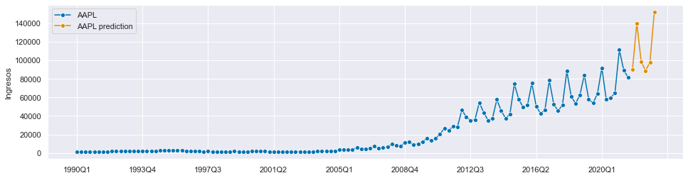

```python
plot_series(y, y_pred, labels=["AAPL", "AAPL prediction"]);
```

#### Estimación del modelo de forma manual (sin componente estacional):

```python
forecaster = ExponentialSmoothing(trend='additive',seasonal=None, sp=4)
forecaster.fit(y)
```

```
ExponentialSmoothing(sp=4, trend='additive')
```

```python
y_pred = forecaster.predict(fh2)
```

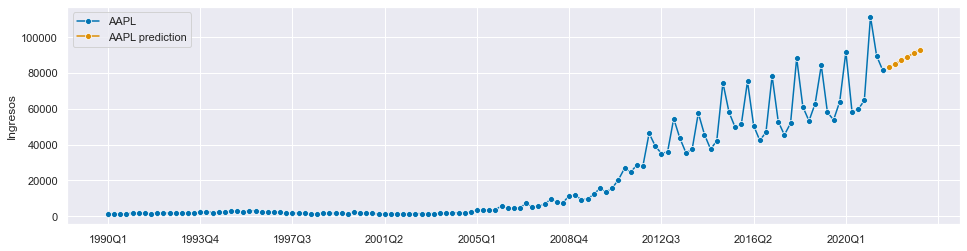

```python
plot_series(y, y_pred, labels=["AAPL", "AAPL prediction"]);
```

#### Estimación del modelo de forma manual (sin componente estacional y con tendencia multiplicativa):

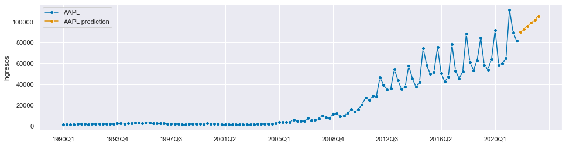

```python
forecaster = ExponentialSmoothing(trend='mul',seasonal=None, sp=4)
forecaster.fit(y)
y_pred = forecaster.predict(fh2)
plot_series(y, y_pred, labels=["AAPL", "AAPL prediction"]);
```

#### Estimación del modelo de forma manual (sin componente estacional y sin tendencia)

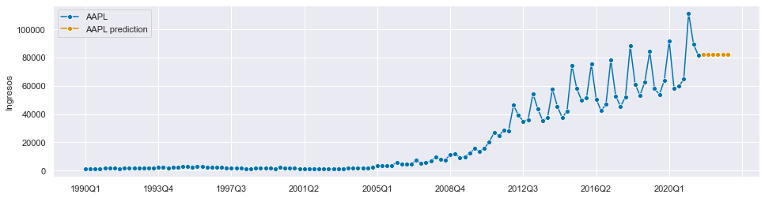

```python
forecaster = ExponentialSmoothing(trend=None,seasonal=None, sp=4)
forecaster.fit(y)
y_pred = forecaster.predict(fh2)
plot_series(y, y_pred, labels=["AAPL", "AAPL prediction"]);
```

#### Estimación del modelo de forma manual (con componente estacional multiplicativo y sin tendencia):

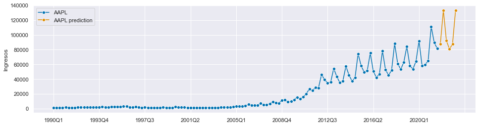

```python
forecaster = ExponentialSmoothing(trend=None,seasonal="mul", sp=4)
forecaster.fit(y)
y_pred = forecaster.predict(fh2)
plot_series(y, y_pred, labels=["AAPL", "AAPL prediction"]);
```

#### Estimación del modelo de forma manual (con componente estacional aditivo y sin tendencia)

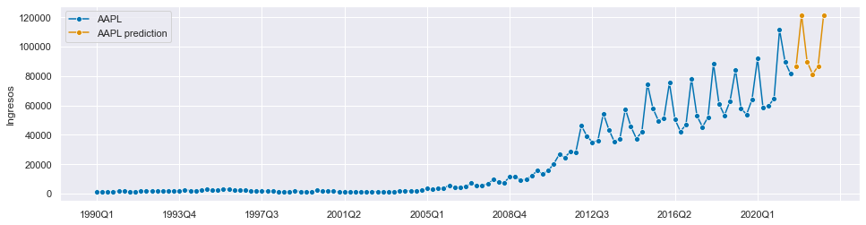

```python
forecaster = ExponentialSmoothing(trend=None,seasonal="add", sp=4)
forecaster.fit(y)
y_pred = forecaster.predict(fh2)
plot_series(y, y_pred, labels=["AAPL", "AAPL prediction"]);
```

#### Comparación del modelo con componente estacional aditivo y tendencia aditiva (con y sin dumped):

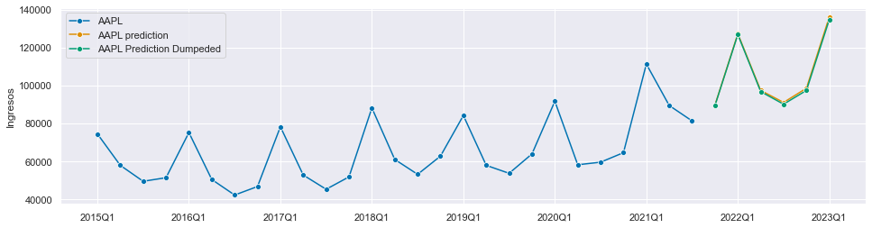

```python
forecaster = ExponentialSmoothing(trend="add",seasonal="add",damped_trend=False, sp=4)
forecaster.fit(y)
y_pred = forecaster.predict(fh2)

forecaster = ExponentialSmoothing(trend="add",seasonal="add",damped_trend=True, sp=4)
forecaster.fit(y)
y_pred_dump = forecaster.predict(fh2)
plot_series(y["2015":], y_pred, y_pred_dump,labels=["AAPL", "AAPL prediction","AAPL Prediction Dumpeded"]);
```

## III. Modelos ARIMA

```python
apple_ts_q = apple_df['Ingresos'].astype('float64').to_period('Q-OCT').sort_index()

apple_ts_q.tail()
```

```
fecha
2020Q3     59685.0
2020Q4     64698.0
2021Q1    111439.0
2021Q2     89584.0
2021Q3     81434.0
Freq: Q-OCT, Name: Ingresos, dtype: float64
```

A continuación, se realiza la transformacion logarítmica de la serie original

```python
transformer = LogTransformer()

log_apple_ts_q = transformer.fit_transform(apple_ts_q)

log_apple_ts_q
```

```
fecha
1990Q1     7.308811
1990Q2     7.205041
1990Q3     7.218763
1990Q4     7.210892
1991Q1     7.423867
            ...
2020Q3    10.996836
2020Q4    11.077486
2021Q1    11.621233
2021Q2    11.402932
2021Q3    11.307548
Freq: Q-OCT, Name: Ingresos, Length: 127, dtype: float64
```

Se comparan la **serie original** y la **serie transformada logarítmicamente**:

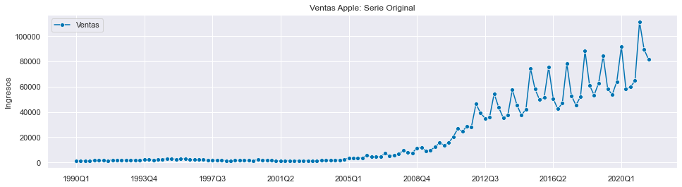

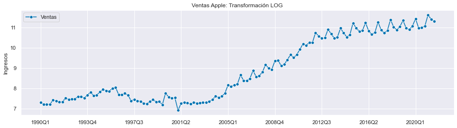

```python
fig, ax =plot_series(apple_ts_q, labels=["Ventas"])

ax.set_title('Ventas Apple: Serie Original');

fig, ax =plot_series(log_apple_ts_q, labels=["Ventas"])

ax.set_title('Ventas Apple: Transformación LOG');
```

Cálculo de la autocorrelación de la Serie en Logs:

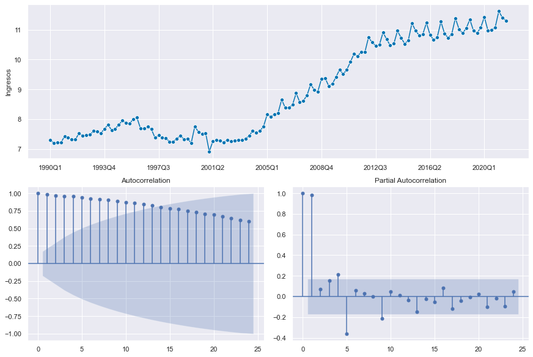

```python
plot_correlations(log_apple_ts_q);
```

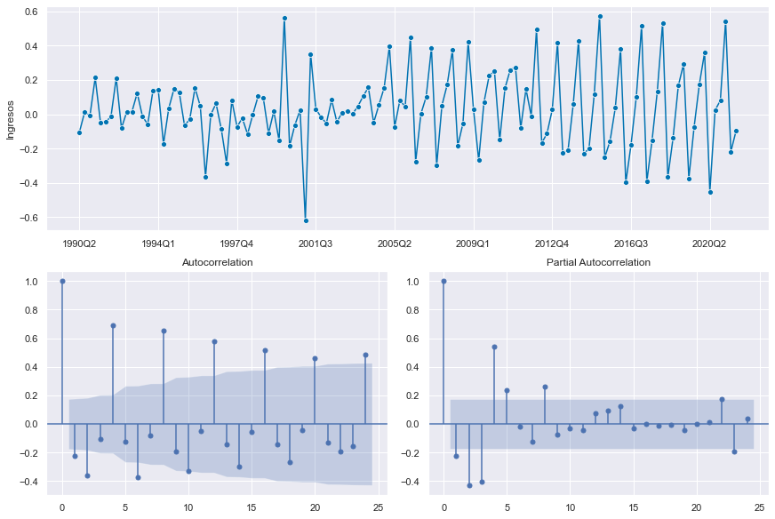

```python
# Función de autocorrelación:
# Parámetros: d=1; D=0; S=4

transf_diff=Differencer(lags=[1])
plot_correlations(transf_diff.fit_transform(log_apple_ts_q));
```

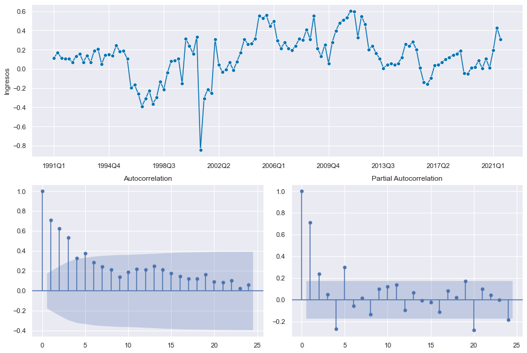

```python
# Función de autocorrelación:
# Parámetros: d=0; D=1; S=4

transf_diff=Differencer(lags=[4])
plot_correlations(transf_diff.fit_transform(log_apple_ts_q));
```

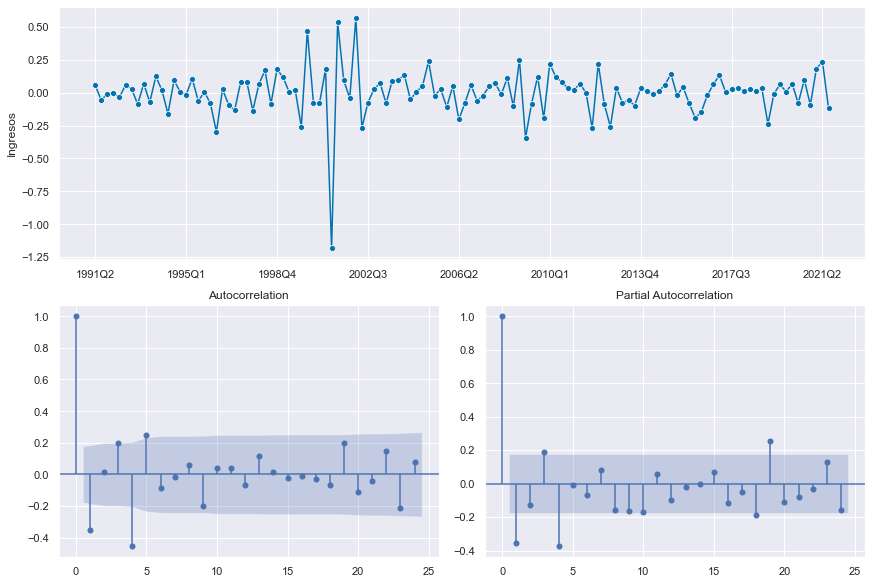

```python
# Función de autocorrelación:
# Parámetros: d=1; D=1; S=4

transf_diff=Differencer(lags=[1,4])
plot_correlations(transf_diff.fit_transform(log_apple_ts_q));
```

Como se hizo anteriormente, se separa la muestra en la parte de estimación (Training) y la parte de predicción (Testing). Se quitan los últimos 8 trimestres (2 años) y a continuación se procede a predecirlos:

```
119 8
```

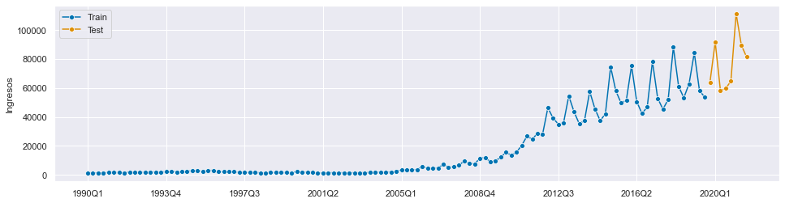

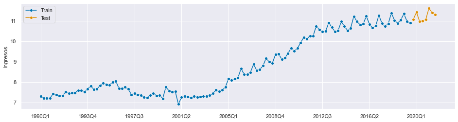

```python
log_y_train, log_y_test = temporal_train_test_split(y=log_apple_ts_q, test_size=8)

plot_series(y_train, y_test, labels=["Train", "Test"])

plot_series(log_y_train, log_y_test, labels=["Train", "Test"])

print(y_train.shape[0], y_test.shape[0])
```

```python
# Estimación del horizonte temporal de predicción (forecasting horizon 'fh'):
fh = np.arange(len(y_test)) + 1
fh
```

```
array([1, 2, 3, 4, 5, 6, 7, 8])
```

```python
# Modelo AutoARIMA:

forecaster = AutoARIMA(sp=4, suppress_warnings=True)

forecaster.fit(log_y_train)
```

```
AutoARIMA(sp=4, suppress_warnings=True)
```

```python
print(forecaster.summary())
```

```
                                     SARIMAX Results
=========================================================================================
Dep. Variable:                                 y   No. Observations:                  119
Model:             SARIMAX(0, 1, 1)x(1, 0, 1, 4)   Log Likelihood                  58.362
Date:                           Tue, 02 Nov 2021   AIC                           -108.724
Time:                                   10:36:00   BIC                            -97.642
Sample:                                        0   HQIC                          -104.224
                                           - 119
Covariance Type:                             opg
==============================================================================
                 coef    std err          z      P>|z|      [0.025      0.975]
------------------------------------------------------------------------------
ma.L1         -0.3363      0.089     -3.795      0.000      -0.510      -0.163
ar.S.L4        0.9156      0.062     14.821      0.000       0.794       1.037
ma.S.L4       -0.4810      0.106     -4.547      0.000      -0.688      -0.274
sigma2         0.0211      0.002     12.465      0.000       0.018       0.024
===================================================================================
Ljung-Box (L1) (Q):                   0.00   Jarque-Bera (JB):               552.10
Prob(Q):                              0.98   Prob(JB):                         0.00
Heteroskedasticity (H):               1.49   Skew:                            -1.49
Prob(H) (two-sided):                  0.22   Kurtosis:                        13.17
===================================================================================

Warnings:
[1] Covariance matrix calculated using the outer product of gradients (complex-step).
```

Predicción de las últimas ventas por modelo AutoARIMA (en forma logarítmica):

```python
log_y_pred = forecaster.predict(fh)

log_y_pred
```

```
2019Q4    11.005157
2020Q1    11.335666
2020Q2    11.027210
2020Q3    10.934799
2020Q4    11.039457
2021Q1    11.342056
2021Q2    11.059648
2021Q3    10.975041
Freq: Q-OCT, dtype: float64
```

Predicción de las últimas ventas por modelo AutoARIMA (en forma de Serie Original):

```python
apple_pred_arima = np.exp(log_y_pred)

apple_pred_arima
```

```
2019Q4    60183.708838
2020Q1    83756.260328
2020Q2    61525.696167
2020Q3    56094.858615
2020Q4    62283.825619
2021Q1    84293.129395
2021Q2    63554.172255
2021Q3    58398.239427
Freq: Q-OCT, dtype: float64
```

**Comprobación de la precisión de las predicciones**

Realización de las funciones SKtime de precisión de la predicción

MAPE (Serie logarítmica)

```python
mean_absolute_percentage_error(log_y_test, log_y_pred)
```

```
0.014049831625058132
```

MAPE (Serie original)

```python
mape2 = mean_absolute_percentage_error(y_test, np.exp(log_y_pred))
```

```python
mape2
```

[output not shown]

RMSE (Serie logarítmica)

```python
rmse = MeanSquaredError(square_root=True)

rmse(log_y_test, log_y_pred)
```

```
0.20211999448075801
```

RMSE (Serie original)

```python
rmse = MeanSquaredError(square_root=True)

rmse(y_test, np.exp(log_y_pred))
```

```
16023.475008705665
```

Representación gráfica de las ventas pasadas y de sus respectivas predicciones:

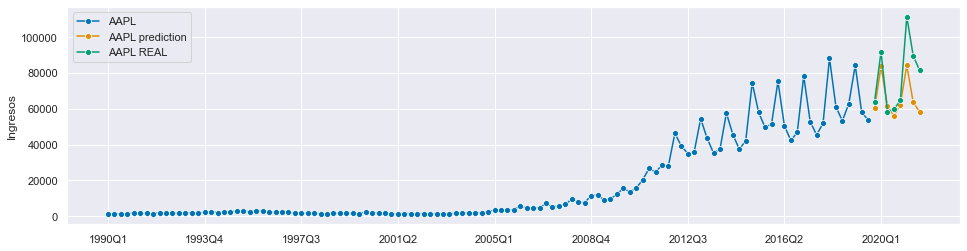

```python
plot_series(y_train, apple_pred_arima, y_test, labels=["AAPL", "AAPL prediction", "AAPL REAL"]);
```

Como ocurría en el modelo ETS, este modelo predice por debajo de lo que dicen los datos reales de Apple, aunque ARIMA, en este caso, ha sido algo más preciso.

#### Predicción de las ventas desde 2021-Q3 a 2022-Q4:

```python
# Estimación del horizonte temporal de predicción (forecasting horizon 'fh'):

fh = np.arange(6) + 1

fh
```

```
array([1, 2, 3, 4, 5, 6])
```

```python
# Modelo AutoARIMA:

forecaster = AutoARIMA(sp=4,suppress_warnings=True)

forecaster.fit(log_apple_ts_q)
```

```
AutoARIMA(sp=4, suppress_warnings=True)
```

```python
# Modelo AutoARIMA:

print(forecaster.summary())
```

```
                                      SARIMAX Results
===========================================================================================
Dep. Variable:                                   y   No. Observations:                  127
Model:             SARIMAX(2, 1, 0)x(1, 0, [1], 4)   Log Likelihood                  64.270
Date:                             Tue, 02 Nov 2021   AIC                           -118.539
Time:                                     10:36:11   BIC                           -104.358
Sample:                                          0   HQIC                          -112.778
                                             - 127
Covariance Type:                               opg
==============================================================================
                 coef    std err          z      P>|z|      [0.025      0.975]
------------------------------------------------------------------------------
ar.L1         -0.3230      0.079     -4.097      0.000      -0.478      -0.168
ar.L2         -0.1575      0.147     -1.070      0.285      -0.446       0.131
ar.S.L4        0.9366      0.049     19.086      0.000       0.840       1.033
ma.S.L4       -0.5384      0.097     -5.535      0.000      -0.729      -0.348
sigma2         0.0204      0.002     12.501      0.000       0.017       0.024
===================================================================================
Ljung-Box (L1) (Q):                   0.00   Jarque-Bera (JB):               566.42
Prob(Q):                              0.99   Prob(JB):                         0.00
Heteroskedasticity (H):               0.99   Skew:                            -1.41
Prob(H) (two-sided):                  0.99   Kurtosis:                        13.00
===================================================================================

Warnings:
[1] Covariance matrix calculated using the outer product of gradients (complex-step).
```

```python
# Predicción de las ventas los 6 futuros trimestres por modelo AutoARIMA (en forma logarítmica):

log_y_pred = forecaster.predict(fh)

log_y_pred
```

```
2021Q4    11.406399
2022Q1    11.810573
2022Q2    11.532825
2022Q3    11.470457
2022Q4    11.565869
2023Q1    11.939253
Freq: Q-OCT, dtype: float64
```

```python
# Predicción de las ventas los 6 futuros trimestres por modelo AutoARIMA (en forma de Serie Original):

apple_pred_arima22 = np.exp(log_y_pred)

apple_pred_arima22
```

```
2021Q4     89895.082375
2022Q1    134668.745584
2022Q2    102009.839152
2022Q3     95842.027506
2022Q4    105436.982656
2023Q1    153162.188152
Freq: Q-OCT, dtype: float64
```

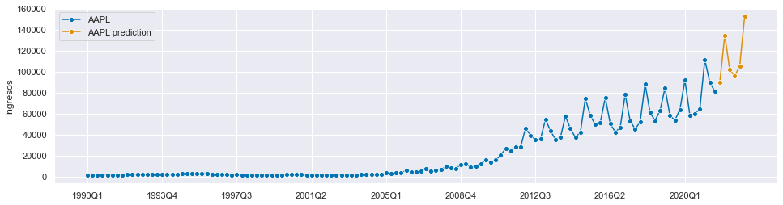

```python
# Representación gráfica de las predicciones a futuro de las ventas de AAPL (2021-Q3 a 2022-Q4),

# Por modelo AutoARIMA:

plot_series(apple_ts_f['Ingresos'].astype('float64').to_period('Q-OCT'), apple_pred_arima22, labels=["AAPL", "AAPL prediction"]);
```

## IV. ETS vs ARIMA

Se procede a continuación a la comparación de las predicciones de ambos modelos:

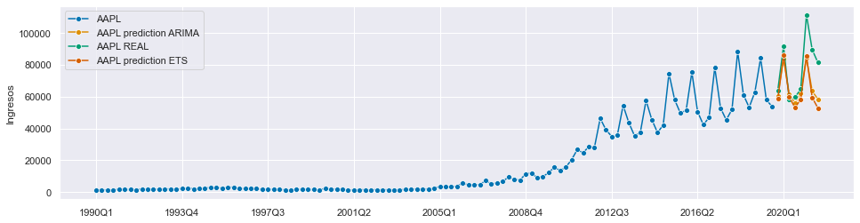

```python
plot_series(y_train, apple_pred_arima, y_test, apple_pred, labels=["AAPL", "AAPL prediction ARIMA", "AAPL REAL","AAPL prediction ETS"]);
```

Como no se aprecia con mucha claridad, se hace un zoom desde el 2015 en adelante:

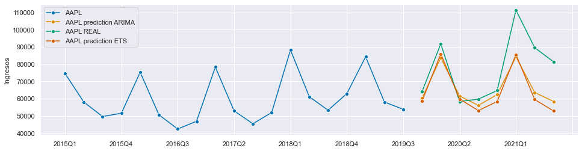

```python
plot_series(y_train['2015':], apple_pred_arima, y_test, apple_pred, labels=["AAPL", "AAPL prediction ARIMA", "AAPL REAL","AAPL prediction ETS"]);
```

Como se comentó anteriormente, ambos modelos predicen por debajo de lo que dicen los datos reales de Apple, pero ARIMA se ha aproximado más.

## V. Efecto COVID

Se procede a crear un data frame con el modelo ARIMA y SME para poder trabajarlo con más comodidad:

```python
df=pd.DataFrame({'Datos reales':y_test,'Datos ARIMA':apple_pred_arima.round(1),
                 'Diferencia':(y_test-apple_pred_arima).round(1),
                 'Diferencia porcentual':(y_test-apple_pred_arima)/apple_pred_arima})
df
```

|  | Datos reales | Datos ARIMA | Diferencia | Diferencia porcentual |
| --- | --- | --- | --- | --- |
| 2019Q4 | 64040.0 | 60183.7 | 3856.3 | 0.064075 |
| 2020Q1 | 91819.0 | 83756.3 | 8062.7 | 0.096264 |
| 2020Q2 | 58313.0 | 61525.7 | -3212.7 | -0.052217 |
| 2020Q3 | 59685.0 | 56094.9 | 3590.1 | 0.064001 |
| 2020Q4 | 64698.0 | 62283.8 | 2414.2 | 0.038761 |
| 2021Q1 | 111439.0 | 84293.1 | 27145.9 | 0.322041 |
| 2021Q2 | 89584.0 | 63554.2 | 26029.8 | 0.409569 |
| 2021Q3 | 81434.0 | 58398.2 | 23035.8 | 0.394460 |

```python
apple_pred_arima22
```

```
2021Q4     89895.082375
2022Q1    134668.745584
2022Q2    102009.839152
2022Q3     95842.027506
2022Q4    105436.982656
2023Q1    153162.188152
Freq: Q-OCT, dtype: float64
```

```python
df_pred=pd.DataFrame({'ARIMA':apple_pred_arima22.round(1),
                 'Diff %':(y_test-apple_pred_arima)/apple_pred_arima})
```

Se unen los datos reales con las predicciones del modelo ARIMA:

```python
predicctions = apple_ts_f['Ingresos'].astype('float64').to_period('Q-OCT').append(apple_pred_arima22)

yearly_predicctions = predicctions.resample('A-OCT').sum()

yearly_predicctions.pct_change().mul(100).tail(10)
```

```
2014     6.953952
2015    27.856342
2016    -7.968680
2017     6.277808
2018    16.186339
2019    -2.041078
2020     5.512080
2021    35.639977
2022    17.619215
2023   -65.028078
Freq: A-OCT, dtype: float64
```

```python
df_pred=pd.DataFrame({'Año Fiscal':yearly_predicctions.index,'Datos ARIMA':yearly_predicctions.round(1)})
df_pred=df_pred.tail(n=4).set_index('Año Fiscal')
df_pred['Datos de Barclays'] = [274515.0,368925,378619,0]
df_pred['Diferencia porcentual'] = (df_pred['Datos de Barclays'] / df_pred['Datos ARIMA'] -1)*100
df_pred['Crecimiento de ARIMA']=df_pred['Datos ARIMA'].pct_change().mul(100)
df_pred['Crecimiento de Barclays']=df_pred['Datos de Barclays'].pct_change().mul(100)
df_pred = df_pred.head(n=3)
df_pred
```

| Año Fiscal | Datos ARIMA | Datos de Barclays | Diferencia porcentual | Crecimiento de ARIMA | Crecimiento de Barclays |
| --- | --- | --- | --- | --- | --- |
| 2020 | 274515.0 | 274515.0 | 0.000000 | NaN | NaN |
| 2021 | 372352.1 | 368925.0 | -0.920392 | 35.639983 | 34.391563 |
| 2022 | 437957.6 | 378619.0 | -13.548937 | 17.619210 | 2.627634 |